## project

#### last semester i had a seminar about olga neuwirth - a contemporary composer - and a friend of mine had the critic that “every song sounds the same”

#### i want to analyse if the features of her songs are the same or not and if they are not the same i want to take a look on how they changed by time

#### i also want to analyse the character of her music in general - does the features of her music represent her personal character? the texts we read about her in the seminar assumed this - she is a very depressed person and shows this depression in her music (i analysed two of her works, *Bählamms Fest* and *Lost Highway*, and the Valence was about mValence ~0.07 sdValence ~0.05 and meanValence ~ 0.14 and sdValence ~0.13) so this aspect for those work examples is very clear

#### another aspect of her works is the presence of “the other” - this concept draw through her so called “musicstallations” - i am suspicious if this “other” shows in any features (maybe compared to other contemporary composers like Adriana Hölszky or Luigi Nono, whom kind of inspires her)

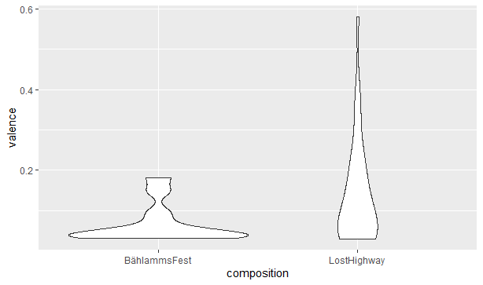

Comparison of the Valence of two compositions